# Statistics and R : EDA and Probability Distribution

syoon

1/7/2021

*These are the notes that were taken during an edx course : Statistics and R*

### **1.General functions**

#### **1.1 sort vs order vs rank in R**

- sort : returnes the sorted data
- order : returns the index required to sort the data
- rank : returns the rank of the data

#### **1.2 Functions to manipulate Data Frame**

- mutate(DataFrame, newcolname = newcolfunction) : adds new coulmn to Data Frame
- filter(DataFrame, filterlogic) : subset of the Data Frame
- select(DataFrame, colname1, colname2, …) : returns only selected column

### **2._norm() functions**

[figure not shown]

- rnorm : 난수생성 : Generate n number of random number based on normal distribution
- dnorm : 확률밀도함수 : Return the Probability density function
- pnorm : 누적분포함수 : Return the Cumulative distribution function
- qnorm : 분위수 : e.g., mean 이랑 sd 가 각각 10, 2 일떄 상위 8%에 해당하는 점수는 무엇인가 = qnorm(0.92, 10, 2, lower.tail = TRUE)

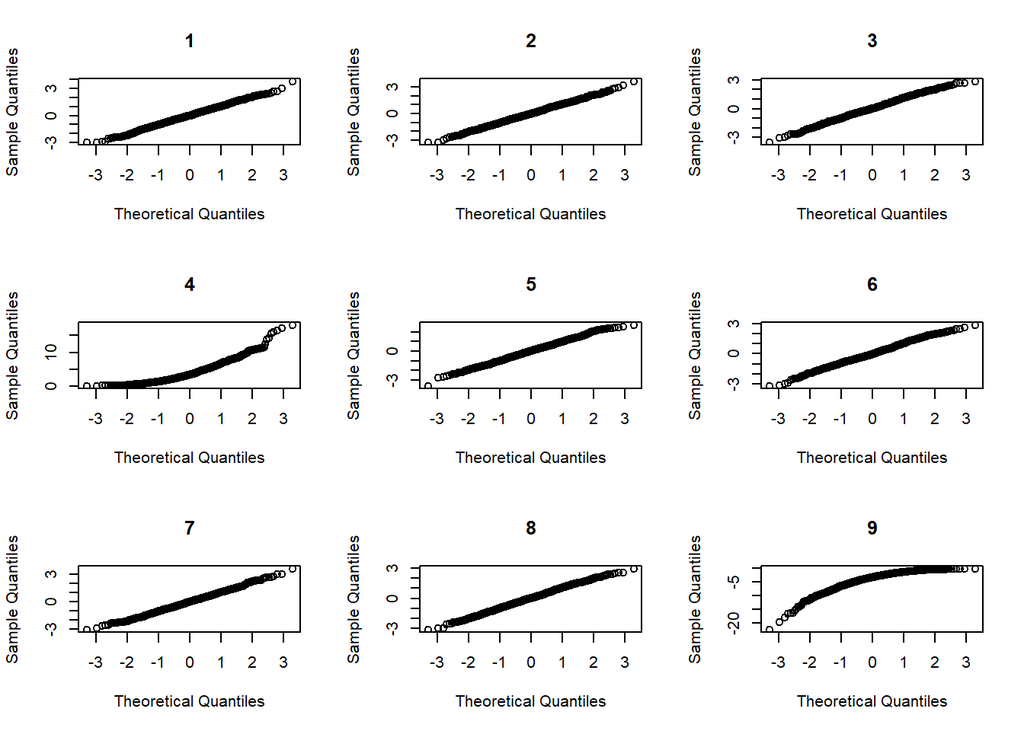

```r
load("skew.RData")
par(mfrow = c(3,3))

for (i in 1:9) {
  qqnorm(dat[,i], main = i)
}
```

For example, through this graph, we can see that the column 4 is positively skewed (long rightside tail) and column 9 is negatively skewed (long leftside tail)

### **3.Creating Box plot**

Box plot shows the distribution of the data in a clear way. It can be generted using the boxplot() function. Note below that the two function generate the same graph.

```r
head(InsectSprays)
```

```
##   count spray
## 1    10     A
## 2     7     A
## 3    20     A
## 4    14     A
## 5    14     A
## 6    12     A
```

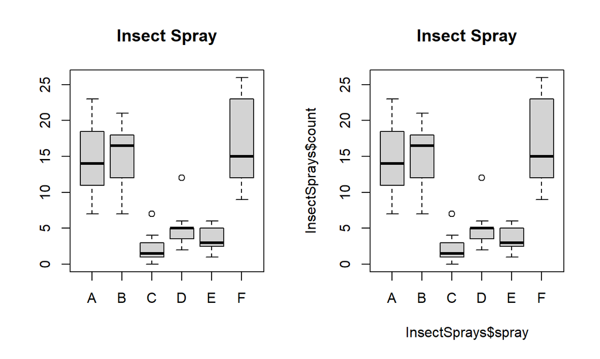

```r
par(mfrow=c(1,2))
boxplot(split(InsectSprays$count,InsectSprays$spray), main = "Insect Spray")
boxplot(InsectSprays$count ~ InsectSprays$spray, main = "Insect Spray")
```

### **4.Null Distribution**

Null Distribution is the probability distribution of the test statistic when the null hypothesis is true. For example, in an F-test, the null distribution is an F-distribution  
Null Hyphothesis 는 두 모수 (e.g., 평균) 에 대한 값이 같다고 가정할 때, reject 또는 accept 하려고 할 떄 세운 Hyphothesi 이며 H0 으로 나타낸다. (H0 : ß1 = ß2) 반대는 대립가설 (alternative hyphothesis)로, 두 모수가 다름을 가정한다. ß1 < ß2 좌측검정, ß1 > ß2 우측검정으로 단측검정, ß1 =/= ß2 은 양측검정이다.  
Let’s assume we want to check if the certain type of diet (high fat : hf) has an impact on the weight of the mice.

```r
library(downloader)
url <- "https://raw.githubusercontent.com/genomicsclass/dagdata/master/inst/extdata/femaleControlsPopulation.csv"
filename <- "femaleControlsPopulation.csv"
if (!file.exists(filename)) download(url,destfile=filename)
pop <- read.csv(filename)
pop <- unlist(pop) # turn it into a numeric
dat <- read.csv("femaleMiceWeights.csv")
```

```r
library(dplyr)
control <- dat %>% filter(Diet == "chow") %>% dplyr::select(Bodyweight) %>% unlist
treatment <- dat %>% filter(Diet == "hf") %>% dplyr::select(Bodyweight) %>% unlist
hypodiff <- mean(treatment) - mean(control)
hypodiff
```

```
## [1] 3.020833
```

```r
n = 10000
null <- vector("numeric",n)

nullfunc <- function(x){
  ctr <- unlist(sample(dat$Bodyweight,12))
  trt <- unlist(sample(dat$Bodyweight,12))
  mean(trt)-mean(ctr)
}

null <- sapply(null, nullfunc)
```

Now we have a vector ‘null’ that stores the difference between treatment group and control group, which does not take diet into consideration. If the ‘null’ is smaller than our hypodiff, meaning the difference in weight is more significant when ‘diet’ was considered, our hypothesis can be concluded as TRUE.

```r
mean(null>=hypodiff)
```

```
## [1] 0.0017
```

We can see that when the diet is not in scope, only during 0.2% of the time is the difference in weight as big as when the diet was in scope( *hypodiff* ). This 0.2% is known as the p-value.

### **5.Probability Distribution**

Probability Distribution describes the likelihood of obtaining a certain value that a random variable can assume.

```r
library(gapminder)
data("gapminder")
life <- gapminder[gapminder$year == 1952,"lifeExp"]
```

We will see for the year 1952, what the probability of a country’s life expectancy being less than x. First, we create a bin-like list for the probability distribution (for probability density, this is unlimited)

```r
#function is similar to ecdf() :  returns the proportion
#creating a bin like list for x
qs <- seq(from = min(life), to = max(life), length = 20)
```

Now we can create a cumulative probability distribution function and a probability density function and plot them. Note that this can be also achieved using the ecdf() function *plot(ecdf(t(life)))* .

- Probability Density Function : Shows the likelihood that the random value will lay between the intervals.
- Cumulative Probabilitx Distribution Function : Shows the probability that the rancom value will be below the certain (x axis) value.

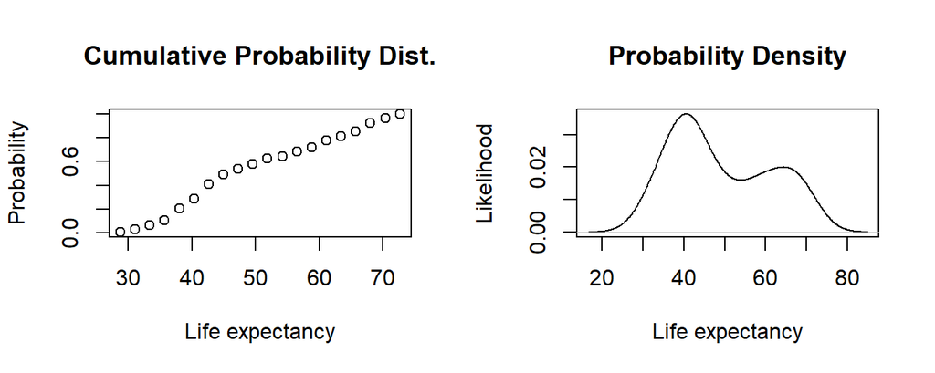

```r
#checking the proportion (probability) for each bin
probs <- sapply(qs, function(q) mean(life<=q))
par(mfrow = c(1,2))
plot(qs,probs, main="Cumulative Probability Dist.", xlab="Life expectancy", ylab="Probability")
plot(density(unlist(life)), main = "Probability Density", xlab="Life expectancy", ylab="Likelihood")
```